# Reproducible science assignment

Anita Høyland

08.10.26

## Introduction

This analysis studies the relation between the swallows wingbeat amplitude and airspeed where airspeed is the predictor and the wingbeat amplitude is the response factor for this. The purpouse is to learn linear regression.

The dataset is based on two different birds with ID 1 and ID 2. Each bird were placed in a wind tunnel where the speed of the airflow could be tampered with. The data is given to us in the BIO415 course, and is available through the link “Parketal2001WBK-2.csv”

Reading the data

```r
library(performance)
library(see)
library(tidyverse)
df_park <- read_csv("Parketal2001WBK-2.csv")
```

quality control

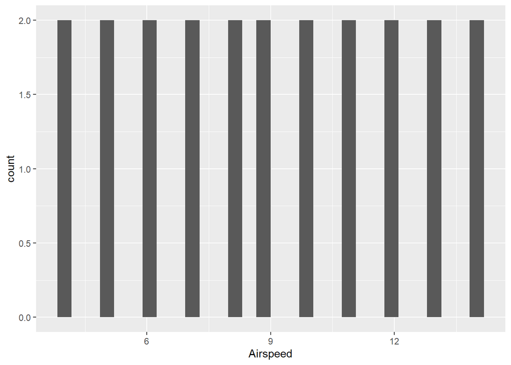

```r
ggplot(data = df_park,
       aes(x = Airspeed)) +
  geom_histogram()
```

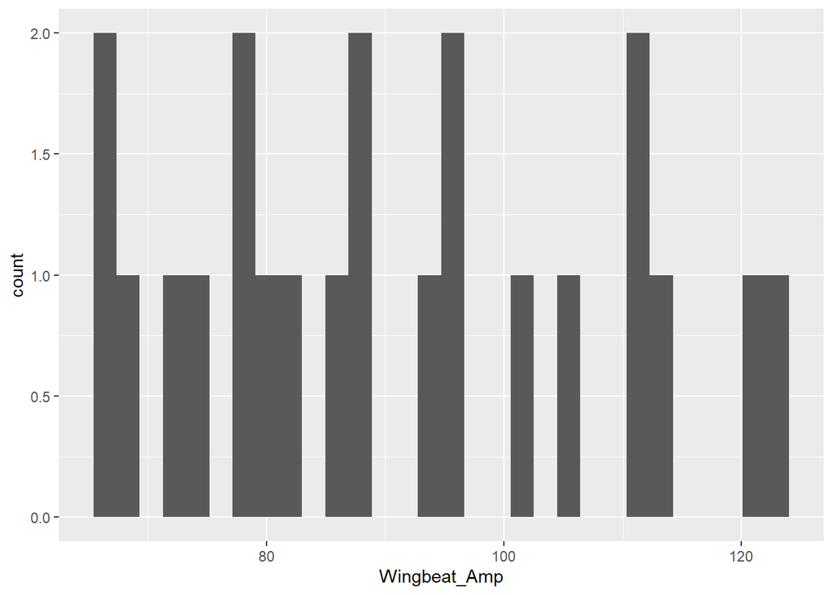

```r
ggplot(data = df_park,
       aes(x = Wingbeat_Amp))+
  geom_histogram()
```

Plotting for the bird with ID 1

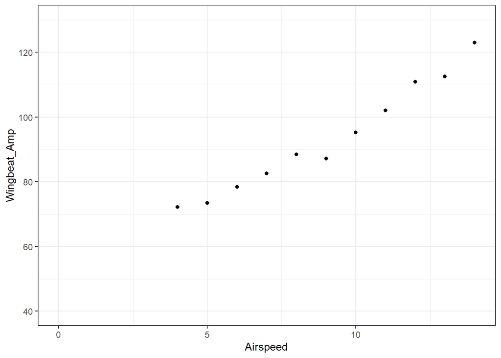

```r
df_park |>
  filter(Bird_ID == 1) |>
  ggplot(aes(x = Airspeed, y = Wingbeat_Amp)) +
  geom_point() +
  xlim(0,14) +
  ylim(40,130) +
  theme_bw()
```

analyzing one of the birds

```r
df_bird1 <- df_park |>
  filter(Bird_ID == 1)
```

regression analysis on bird ID 1

```r
lm_wba_1 <- lm(Wingbeat_Amp ~ Airspeed,
               data = df_bird1)
str(lm_wba_1)
```

[output not shown]

checking the model

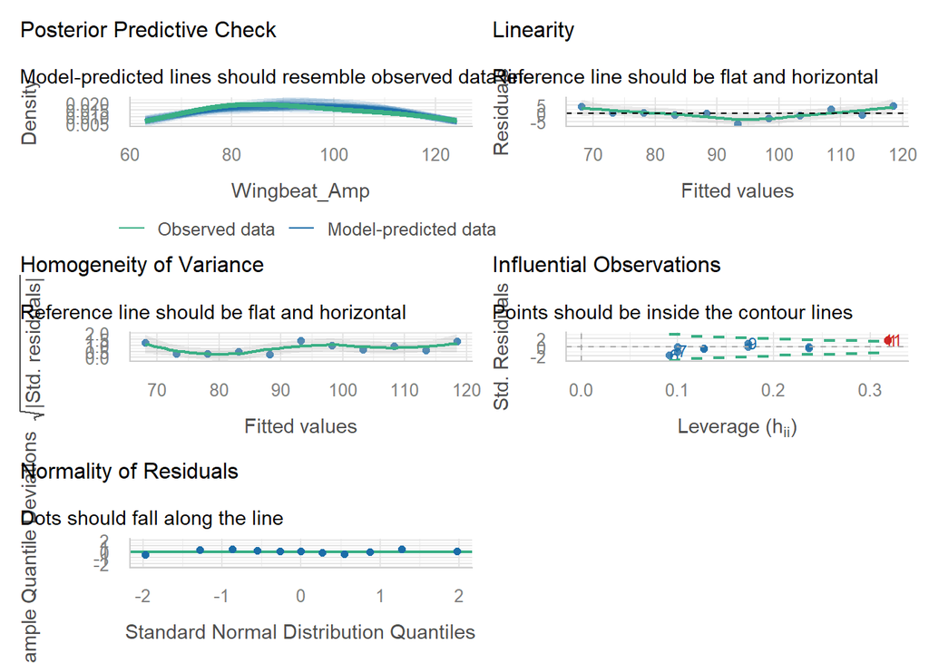

```r
check_model(lm_wba_1)
```

checking sumamry

```r
summary(lm_wba_1)
```

```
##
## Call:
## lm(formula = Wingbeat_Amp ~ Airspeed, data = df_bird1)
##
## Residuals:
##     Min      1Q  Median      3Q     Max
## -6.0427 -1.1243  0.2078  1.4225  4.5966
##
## Coefficients:
##             Estimate Std. Error t value Pr(>|t|)
## (Intercept)   47.988      2.919   16.44 5.08e-08 ***
## Airspeed       5.030      0.306   16.44 5.08e-08 ***
## ---
## Signif. codes:  0 '***' 0.001 '**' 0.01 '*' 0.05 '.' 0.1 ' ' 1
##
## Residual standard error: 3.21 on 9 degrees of freedom
## Multiple R-squared:  0.9678, Adjusted R-squared:  0.9642
## F-statistic: 270.2 on 1 and 9 DF,  p-value: 5.08e-08
```

checking confidence interval

```r
confint(lm_wba_1)
```

```
##                 2.5 %    97.5 %
## (Intercept) 41.384166 54.591798
## Airspeed     4.338259  5.722795
```

updating the model with one subset of data

```r
lm_wba_2 <- update(lm_wba_1, data = df_bird1 [-1,])
summary(lm_wba_1)
```

```
##
## Call:
## lm(formula = Wingbeat_Amp ~ Airspeed, data = df_bird1)
##
## Residuals:
##     Min      1Q  Median      3Q     Max
## -6.0427 -1.1243  0.2078  1.4225  4.5966
##
## Coefficients:
##             Estimate Std. Error t value Pr(>|t|)
## (Intercept)   47.988      2.919   16.44 5.08e-08 ***
## Airspeed       5.030      0.306   16.44 5.08e-08 ***
## ---
## Signif. codes:  0 '***' 0.001 '**' 0.01 '*' 0.05 '.' 0.1 ' ' 1
##
## Residual standard error: 3.21 on 9 degrees of freedom
## Multiple R-squared:  0.9678, Adjusted R-squared:  0.9642
## F-statistic: 270.2 on 1 and 9 DF,  p-value: 5.08e-08
```

```r
summary(lm_wba_2)
```

```
##
## Call:
## lm(formula = Wingbeat_Amp ~ Airspeed, data = df_bird1[-1, ])
##
## Residuals:
##     Min      1Q  Median      3Q     Max
## -5.5046 -1.4282  0.7318  1.8508  3.7895
##
## Coefficients:
##             Estimate Std. Error t value Pr(>|t|)
## (Intercept)  45.0283     3.2049   14.05 6.39e-07 ***
## Airspeed      5.2996     0.3229   16.41 1.92e-07 ***
## ---
## Signif. codes:  0 '***' 0.001 '**' 0.01 '*' 0.05 '.' 0.1 ' ' 1
##
## Residual standard error: 2.933 on 8 degrees of freedom
## Multiple R-squared:  0.9712, Adjusted R-squared:  0.9675
## F-statistic: 269.3 on 1 and 8 DF,  p-value: 1.915e-07
```

predicting the respons variable over a certain range

```r
df_newbird <-
tibble(Airspeed = seq(min(df_bird1$Airspeed),
                      max(df_bird1$Airspeed),
                      length = 100))

df_newbird
```

| Airspeed |
| --- |
| 4.000000 |
| 4.101010 |
| 4.202020 |
| 4.303030 |
| 4.404040 |
| 4.505051 |
| 4.606061 |
| 4.707071 |
| 4.808081 |
| 4.909091 |

[output cut: 90 more lines]

```r
df_preds <- predict(lm_wba_1,
                    newdata = df_newbird,
                    int = "c")
df_newbird_preds <- bind_cols(df_newbird, as_tibble(df_preds))
```

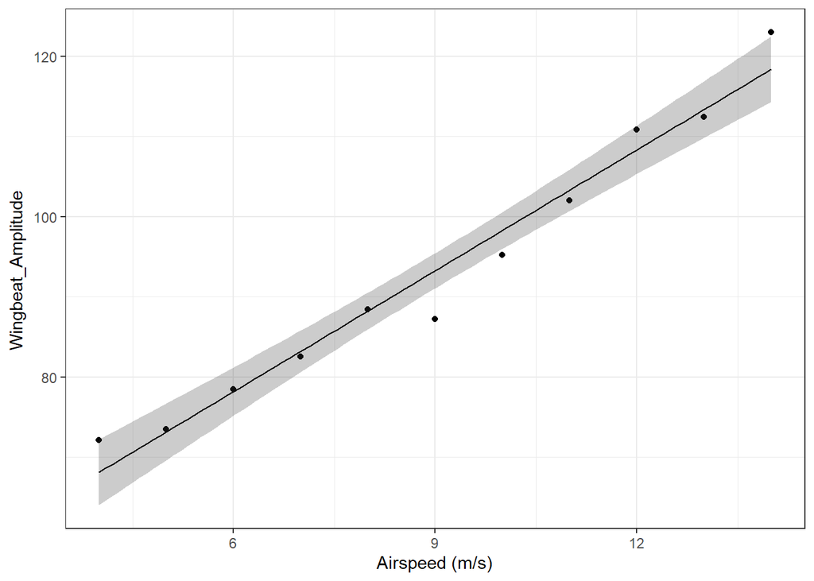

```r
ggplot(df_newbird_preds) +
  aes(x = Airspeed, y = fit) +
  geom_line() +
  geom_point(data = df_bird1, aes(x = Airspeed, y = Wingbeat_Amp)) +
  geom_ribbon(aes(ymin = lwr,
                  ymax = upr),
              alpha = 0.25) +
  labs(x = "Airspeed (m/s)",
       y = expression("Wingbeat_Amplitude")) +
  theme_bw()
```

## Interpretation of results

The model shows a positive relation between the predictor and the response factor. When the airspeed is increased, the wingbeat amplitude also increases.The data is only representative for two individual birds, and one bird species. This is a relevant limitation for beeing able to draw a clean conclusion because the wingbeat amplitude and airspeed tolerance has a clear variation between bird species.